# Data_571_Assignment_1

Connor Fairbanks

11/25/2020

# Q1

```r
salaries <- read.csv('salaries.csv', stringsAsFactors = TRUE)
summary(salaries)
```

```
##         rank     discipline yrs.since.phd    yrs.service        sex
##  AssocProf: 64   A:181      Min.   : 1.00   Min.   : 0.00   Female: 39
##  AsstProf : 67   B:216      1st Qu.:12.00   1st Qu.: 7.00   Male  :358
##  Prof     :266              Median :21.00   Median :16.00
##                             Mean   :22.31   Mean   :17.61
##                             3rd Qu.:32.00   3rd Qu.:27.00
##                             Max.   :56.00   Max.   :60.00
##      salary
##  Min.   : 57800
##  1st Qu.: 91000
##  Median :107300
##  Mean   :113706
##  3rd Qu.:134185
##  Max.   :231545
```

### a)

```r
library(tree)
```

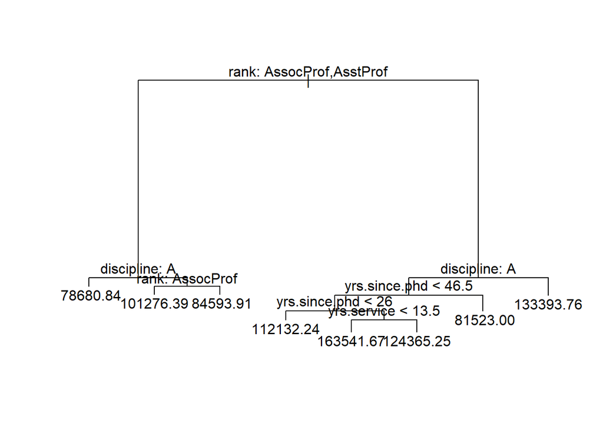

```r
salaryt <- tree(salary~., data=salaries)
plot(salaryt)
text(salaryt, pretty = 0, digits = 8)
```

### b)

One strange result noted is that professors of the rank `Prof` who are of the discipline `A` who have had more than 46.5 years passed since they earned their PhD’s are paid less than similar professors who have had less than 46.5 years pass since they earned their PhD’s. This seems counterintuitive as one would think with more experience comes more pay. One potential explanation for this is the idea that most professors who have had more than 46.5 years that have passed since earning their PhD’s are working part time due to their advanced age and their desire to work less. A part time schedule would not be reflected in the original salary data set, but the salary would be lower due to the lighter workload of the professor.

### c)

Based on this tree, as an Assistant or Associate professor, you would make more money if you were in an applied discipline when compared to a theoretical position. We know this because our first binary division is based on if the professor is an associate or an assistant professor. Since we are only looking at associate and assistant professors, we follow the left ‘Yes’ branch of the first binary decision. The next decision is based on the discipline of those professors. Those in theoretical disciplines follow the left ‘Yes" branch of the second binary decision, and all terminal branches that result from the ’No’ branch of the second binary decision will be in an applied discipline. We can see that the theoretical discipline branch (78680) has a lower average salary than the applied discipline terminal branches (101300, 84590).

### d)

Cross validation suggests using 8 terminal nodes (as seen on the chart below, the predicted RSS is at a minimum when we do no further pruning of the tree and stay with 8 terminal nodes).

The expected MSE for this 20 fold CV is 568514139.

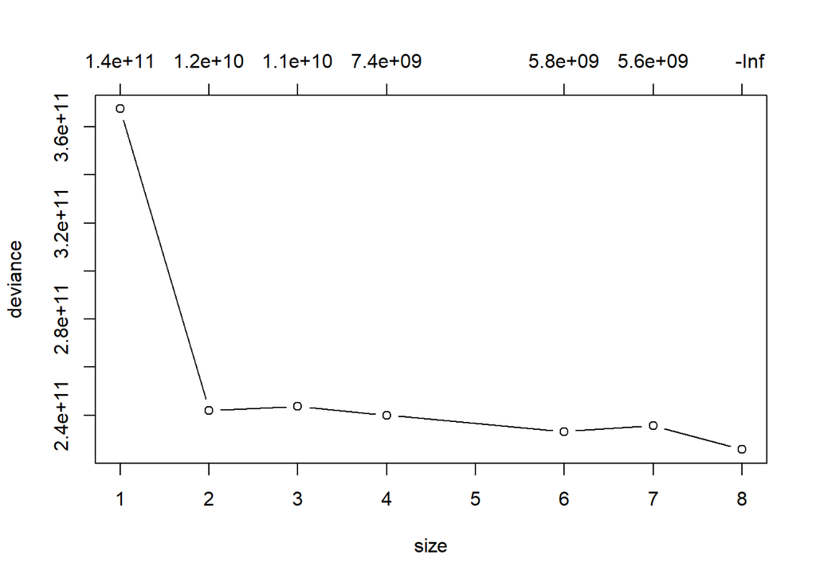

```r
set.seed(6421)
cv.salaryt <- cv.tree(salaryt, K = 20)
plot(cv.salaryt, type = "b")
```

```r
(min(cv.salaryt$dev))/397
```

```
## [1] 568514139
```

### e)

No pruning of the tree was needed as was stated in part d).

```r
andrews = data.frame("rank" = factor(c("AsstProf"), levels =  c("AssocProf", "AsstProf", "Prof")), "discipline" = factor(c("B"), levels = c("A", "B")), "yrs.since.phd" = c(8L), "yrs.service" = c(5L), "sex" = factor(c("Male"), levels = c("Male", "Female")))
andrewspred = predict(salaryt, newdata=andrews)
andrewspred
```

```
##        1
## 84593.91
```

The prediction found using the `predict()` function is what I would expect when I follow the tree logically. Based on the tree, I would think that the prediction for your salary should be 84593.91 because we would answer ‘yes’ to the first binary split (rank of assistant professor), ‘no’ to the second binary split since you teach in an applied discipline (No to discipline A), and then ‘no’ to the third binary split (rank of associate professor since you are an assistant professor).

### f)

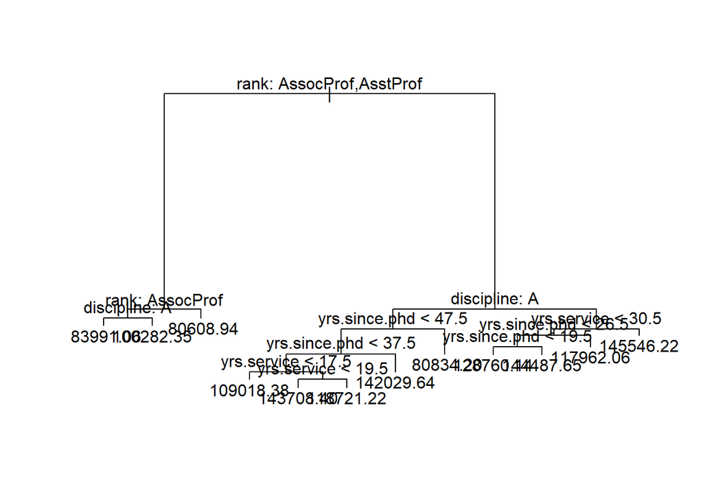

```r
set.seed(763)
trainindex <- sample(1:nrow(salaries), 200)
proftrain <- salaries[trainindex, ]
proftest <- salaries[-trainindex, ]

traint <- tree(salary~., data=proftrain)
plot(traint)
text(traint, pretty = 0, digits = 8)
```

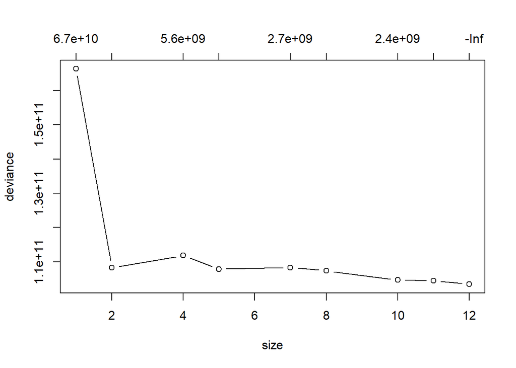

```r
cv.traint = cv.tree(traint, K = 20)
plot(cv.traint, type = "b")
```

```r
andrewspredt = predict(traint, newdata=andrews)
andrewspredt
```

```
##        1
## 80608.94
```

```r
yhat = predict(traint, newdata = proftest)
actual = proftest$salary
testmse = mean(((yhat- actual)^2))
testmse
```

```
## [1] 752262707
```

Your predicted salary using the `traint` tree modeled on the training set of data shown in this question is 80608.94. No further pruning was needed for this tree as seen on the plot of the `cv.traint` which indicates that the deviance (Predicted RSS) of the tree is minimized when there are 12 terminal nodes.

The estimated MSE of the model is 752262707.

### g)

The MSE of the test set = 752262707

The expected MSE (see 1d for the calculation) from d = 568514139

These two values are not very close to each other.

# Q2

I would describe the KNN as the better method in this case. The reason for this is based on the misclassification rates (noting that the CV misclassification rate is a good estimate of test misclassification rate):

KNN train misclassification rate = 10/102 = 0.098

KNN CV misclassification rate = 18/102 = 0.1765

Tree train misclassification rate = 3/102 = 0.0294

Tree CV misclassification rate = 24/102 = 0.2353

When looking at the training misclassification rates only, one may think that the tree is the better method, but the training misclassification rate does not take into account when a model is overfit or poor at predicting new data. The CV misclassification rate will reflect when a model is overfit or poor at predicting new data. The KNN CV misclassification rate is lower than the Tree CV misclassification rate, therefore it is a better method for predicting new data points generated from this data.

# Q3

### a)

```r
set.seed(1111)
x <- runif(30)
cat('The sample mean of x is', mean(x), '\n')
```

```
## The sample mean of x is 0.5259729
```

```r
cat('The sample variance of x is', var(x))
```

```
## The sample variance of x is 0.104982
```

### b)

```r
library(bootstrap)
jfit <- jackknife(x, var)
jackbias <- jfit$jack.bias
jackse <- jfit$jack.se
cat('The jackknife bias of the sample variance for this sample is', jackbias, '\n')
```

```
## The jackknife bias of the sample variance for this sample is 0
```

```r
cat('The jackknife standard error of the sample variance for this sample is', jackse)
```

```
## The jackknife standard error of the sample variance for this sample is 0.01581682
```

### c)

```r
set.seed(2222)
varboot <- bootstrap(x, 1000, var)
mean_var_boot <- mean(varboot$thetastar)
bias_boot <- mean_var_boot - var(x)
se_boot <- sd(varboot$thetastar)
cat('The bootstrap estimate of the bias for the sample variance is', bias_boot, "\n")
```

```
## The bootstrap estimate of the bias for the sample variance is -0.003583375
```

```r
cat('The bootstrap estimate of the standard error of the sample variance is', se_boot)
```

```
## The bootstrap estimate of the standard error of the sample variance is 0.01557276
```

### d)

```r
bv <- varboot$thetastar
quantile(bv, .025)
```

```
##       2.5%
## 0.07098573
```

```r
quantile(bv, .975)
```

```
##    97.5%
## 0.131757
```

```r
print('A 95% bootstrap CI for the population variance from the sample variance is (0.071, 0.132)')
```

```
## [1] "A 95% bootstrap CI for the population variance from the sample variance is (0.071, 0.132)"
```

### e)

```r
val1 <- qchisq(0.975, 30-1)
val2 <- qchisq(0.025, 30-1)
lower_bound <- ((30-1)*var(x))/val1
upper_bound <- ((30-1)*var(x))/val2
lower_bound
```

```
## [1] 0.06658633
```

```r
upper_bound
```

```
## [1] 0.1897218
```

```r
print('The improper 95% CI which assumes x is normally distributed is (0.067, 0.190)')
```

```
## [1] "The improper 95% CI which assumes x is normally distributed is (0.067, 0.190)"
```

### f)

The improper CI includes a wider range of values than the bootstrap CI. The bootstrap CI would be more accurate because it is based on many samples from x which is actually a random sample from a uniform distribution. The improper CI is assuming x is normally distributed. The wider range of the improper CI would actually be a larger than a 95% CI for the sample x. This means that if many samples were taken, more than 95% of the time, the CI interval calculated from that sample would contain the true variance of the population the x was sampled from.

### g)

```r
1/12
```

```
## [1] 0.08333333
```

The true variance is contained in both of the intervals discussed above.

### h)

```r
998/1000
```

```
## [1] 0.998
```

```r
941/1000
```

```
## [1] 0.941
```

The two resulting numbers printed out represent how many times (out of 1000 trials) the confidence intervals that were produced from the samples using the normal distribution assumption formula or the bootstrap approach, actually contained the true variance of the sample population.

The improper 95% CI is more accurately (as estimated by 1000 samples) more like a 99.8% CI. The fact that x was not normally distributed accounts for the fact that the improper CI has too wide of a range and contains the true population variance much more often than the expected 95% of the time.

The bootstrap 95% CI was closer to what we expected to see. The 1000 bootstrap sample CI’s contained the true population variance 94.1% of the time, and we expected them to contain the true population variance 95% of the time.